# Problem Set 1

Due January 29th midnight

### Before You Start

Make sure to at least take a basic tutorial in the IPython notebook, otherwise you'll be totally lost. For this problem set, you should download flights.csv.bz2 and weather.csv.bz2 datasets from Canvas (files-data). Rename the notebook to LASTNAME_FIRSTNAME-PS1.ipynb.

When done, please submit

1. the notebook itself
2. the rendered html or pdf of it.

It is all fine to discuss the problems and way how to solve these with your classmates and instructors. However, the solutions must be your own. Don't copy-paste each other solutions!

## About the Problem Set:

This problem set is rather similar to ones used for R, dplyr, and flights data. Just we use python and pandas.

Your task is to analyze the nycflights13 data (in the R package of the same name). The necessary csv files are provided on canvas (in files/data). An easy way to get the explanations is on the the [package page on R documentation](https://www.rdocumentation.org/packages/nycflights13/versions/1.0.0).

In this problem set you will perform a basic exploratory analysis on an example dataset, bringing to bear all of your new skills in data manipulation and visualization. You will be required to submit well commented python code, documenting all code used in this problem set, along with a write up answering all questions below. Use figures as appropriate to support your answers, and when required by the problem.

Always comment your results, preferably in a separate markdown cell.

## Preliminaries

You should also make sure the following libraries load correctly. Below are a few basic data description tasks already done for you.

```python
#IPython is what you are using now to run the notebook
import IPython
print( "IPython version:      %6.6s (need at least 1.0)" % IPython.__version__)

import os

# Numpy is a library for working with arrays and matrices
import numpy as np
print( "Numpy version:        %6.6s (need at least 1.7.1)" % np.__version__)

# SciPy implements many different numerical algorithms
import scipy as sp
print( "SciPy version:        %6.6s (need at least 0.12.0)" % sp.__version__)

# Pandas makes working with data tables easier
import pandas as pd
print( "Pandas version:       %6.6s (need at least 0.11.0)" % pd.__version__)

# Module for plotting
import matplotlib.pyplot as plt
from pylab import *
print( "Mapltolib version:    %6.6s (need at least 1.2.1)" %
       matplotlib.__version__)
%matplotlib inline
# necessary for in-line graphics

#Seaborn for different style plots
import seaborn as sns; sns.set()
print( "Seaborn version:      %6.6s" % sns.__version__)

# SciKit Learn implements several Machine Learning algorithms
import sklearn
print( "Scikit-Learn version: %6.6s (need at least 0.13.1)" %
       sklearn.__version__)

# for certain system-related functions
```

```
IPython version:       6.1.0 (need at least 1.0)
Numpy version:        1.13.1 (need at least 1.7.1)
SciPy version:        0.19.1 (need at least 0.12.0)
Pandas version:       0.20.3 (need at least 0.11.0)
Mapltolib version:     2.0.2 (need at least 1.2.1)
Seaborn version:       0.8.0
Scikit-Learn version: 0.19.0 (need at least 0.13.1)
```

```python
## Let's read the data and print some summary information
## adjust the path for your file system!
## you can find the path like this:
path = os.getcwd()
print(path)
flights_df= pd.read_csv('C:/Users/mailt/Documents/IMT574/data/flights.csv.bz2')
```

```
C:\Users\mailt\Documents\IMT574
```

```python
## Extract some basic information about the data like number of rows,
## columns, column names, data types
print(flights_df.shape)
print(flights_df.columns)
print(flights_df.dtypes)
```

```
(336776, 17)
Index(['Unnamed: 0', 'year', 'month', 'day', 'dep_time', 'dep_delay',
       'arr_time', 'arr_delay', 'carrier', 'tailnum', 'flight', 'origin',
       'dest', 'air_time', 'distance', 'hour', 'minute'],
      dtype='object')
Unnamed: 0      int64
year            int64
month           int64
day             int64
dep_time      float64
dep_delay     float64
arr_time      float64
arr_delay     float64
carrier        object
tailnum        object
flight          int64
origin         object
dest           object
air_time      float64
distance        int64
hour          float64
minute        float64
dtype: object
```

```python
## print the first and last few lines of the data
print("head\n", flights_df.head())
print("tail\n", flights_df.tail())
## Find the number of unique destinations in the data ('dest')
print("destinations:\n", flights_df.dest.unique())
```

```
head
    Unnamed: 0  year  month  day  dep_time  dep_delay  arr_time  arr_delay  \
0           1  2013      1    1     517.0        2.0     830.0       11.0
1           2  2013      1    1     533.0        4.0     850.0       20.0
2           3  2013      1    1     542.0        2.0     923.0       33.0
3           4  2013      1    1     544.0       -1.0    1004.0      -18.0
4           5  2013      1    1     554.0       -6.0     812.0      -25.0

  carrier tailnum  flight origin dest  air_time  distance  hour  minute
0      UA  N14228    1545    EWR  IAH     227.0      1400   5.0    17.0
1      UA  N24211    1714    LGA  IAH     227.0      1416   5.0    33.0
2      AA  N619AA    1141    JFK  MIA     160.0      1089   5.0    42.0
3      B6  N804JB     725    JFK  BQN     183.0      1576   5.0    44.0
4      DL  N668DN     461    LGA  ATL     116.0       762   5.0    54.0
tail
         Unnamed: 0  year  month  day  dep_time  dep_delay  arr_time  \
336771      336772  2013      9   30       NaN        NaN       NaN
336772      336773  2013      9   30       NaN        NaN       NaN
336773      336774  2013      9   30       NaN        NaN       NaN
336774      336775  2013      9   30       NaN        NaN       NaN
336775      336776  2013      9   30       NaN        NaN       NaN

        arr_delay carrier tailnum  flight origin dest  air_time  distance  \
336771        NaN      9E     NaN    3393    JFK  DCA       NaN       213
336772        NaN      9E     NaN    3525    LGA  SYR       NaN       198
336773        NaN      MQ  N535MQ    3461    LGA  BNA       NaN       764
336774        NaN      MQ  N511MQ    3572    LGA  CLE       NaN       419
336775        NaN      MQ  N839MQ    3531    LGA  RDU       NaN       431

        hour  minute
336771   NaN     NaN
336772   NaN     NaN
336773   NaN     NaN
336774   NaN     NaN
336775   NaN     NaN
destinations:
 ['IAH' 'MIA' 'BQN' 'ATL' 'ORD' 'FLL' 'IAD' 'MCO' 'PBI' 'TPA' 'LAX' 'SFO'
 'DFW' 'BOS' 'LAS' 'MSP' 'DTW' 'RSW' 'SJU' 'PHX' 'BWI' 'CLT' 'BUF' 'DEN'
 'SNA' 'MSY' 'SLC' 'XNA' 'MKE' 'SEA' 'ROC' 'SYR' 'SRQ' 'RDU' 'CMH' 'JAX'
 'CHS' 'MEM' 'PIT' 'SAN' 'DCA' 'CLE' 'STL' 'MYR' 'JAC' 'MDW' 'HNL' 'BNA'
 'AUS' 'BTV' 'PHL' 'STT' 'EGE' 'AVL' 'PWM' 'IND' 'SAV' 'CAK' 'HOU' 'LGB'
 'DAY' 'ALB' 'BDL' 'MHT' 'MSN' 'GSO' 'CVG' 'BUR' 'RIC' 'GSP' 'GRR' 'MCI'
 'ORF' 'SAT' 'SDF' 'PDX' 'SJC' 'OMA' 'CRW' 'OAK' 'SMF' 'TUL' 'TYS' 'OKC'
 'PVD' 'DSM' 'PSE' 'BHM' 'CAE' 'HDN' 'BZN' 'MTJ' 'EYW' 'PSP' 'ACK' 'BGR'
 'ABQ' 'ILM' 'MVY' 'SBN' 'LEX' 'CHO' 'TVC' 'ANC' 'LGA']
```

## Some Tips

- This assignment involves extensive Data frame splitting and aggregation. You should look into the details of the methods groupby, transform, sum, count, mean etc
- Many of the tasks in the assignment can be done either through the Pandas Data Frame or by converting the data frames to Series. Many of the methods in the numpy are applicable to Series only. When stuck, try to explore the type of object (Pandas Data Frame or Numpy Series) you are dealing with.

## Question 1

Let’s explore flights from NYC to LA. Use the flights dataset to answer the following questions.

### (a)

How many flights were there from NYC airports to Los Angeles International Airport (LAX) in 2013?

```python
#Count the number of rows by the unique value in the the column 'dest' as it contains the destination
dest_countList = flights_df.dest.value_counts()

#Get the count of rows with dest as 'LAX'
No_of_flights_To_LAX = dest_countList['LAX']
No_of_flights_To_LAX
```

```
16174
```

#### There were 16174 flights in total from NYC airports to Los Angeles International airport (LAX) in 2013

### (b)

Which airline ('carrier') has the most flights from NYC to LAX? Which one has the least number of flights? Report the numbers respectively.

```python
#Filter all the rows with 'dest' as 'LAX'
flights_To_LAX = flights_df[flights_df.dest == 'LAX']

#Count the number of rows by the unique value in the the column 'carrier' as it contains the destination
carrier_countList = flights_To_LAX.carrier.value_counts()

#Get the count for the carrier with most number of flights
most_flights_count = carrier_countList.max()
most_flights_count
#Get the Carrier with most no of flights
most_flights_carrier = carrier_countList.idxmax()
most_flights_carrier

#Get the count for the carrier with least number of flights
least_flights_count = carrier_countList.min()
least_flights_count
#Get the Carrier with least no of flights
least_flights_carrier = carrier_countList.idxmin()
least_flights_carrier
```

```
'B6'
```

#### The carrier with most number of flights is UA(United Air Lines Inc.) with 5823 flights

#### The carrier with minimum number of flights is B6( SkyWest Airlines Inc.) with 1688 flights

### (c)

How many unique air planes fly from NYC to LAX? (Hint: use 'tailnum', essentially the license plate of airplane)

```python
#To get the unique airplanes in the data using 'tailnum' attribute
unique_planes = flights_To_LAX.tailnum.unique()

#Find the count of unique airplanes
unique_planes_count = len(unique_planes)
unique_planes_count
```

```
992
```

#### There were 992 unique air planes that fly from NYC to LAX

### (d)

What is the average arrival delay for flights from NYC to LAX?

```python
#Find the average arrival delay for flights from NYC to LAX
#Group by the 'dest' and find the mean of 'arr_delay' column
avg_arr_delayList = flights_df.groupby('dest')['arr_delay'].aggregate('mean')
avg_arr_delayList

#Get the average arrival delay for LAX
avg_arr_delay_LAX = avg_arr_delayList['LAX']
avg_arr_delay_LAX
```

```
0.54711094471483834
```

#### The average arrival delay for flights from NYC to LAX is 0.5471 minutes

### (e)

What proportion of flights to LAX come from each NYC airport?

```python
#Group by the origin to find the counts for each
grouped_count = flights_To_LAX.groupby('origin').size()

#To calculate proportion
prop_EWR = grouped_count['EWR']/grouped_count.sum()
prop_EWR
prop_JFK = grouped_count['JFK']/grouped_count.sum()
prop_JFK
```

```
0.69630270804995675
```

#### There are flights only from two airports of NYC 'EWR' and 'JFK' and their proportions are as follows.

##### EWR: 0.3037

##### JFK: 0.6963

## Question 2

Now let's explore the entire NYC flight dataset. Flights are often delayed. Consider the following questions exploring delay patterns.

### (a)

Which date has the largest average departure delay? Which date has the largest average arrival delay?

```python
#### Departure Delay
#Group by date and use mean aggregate on departure delay
avg_dep_delay_byDate = flights_df.groupby(['year', 'month', 'day'])['dep_delay'].aggregate('mean')

#### Arrival Delay
#Group by date and use mean aggregate on arrival delay
avg_arr_delay_byDate = flights_df.groupby(['year', 'month', 'day'])['arr_delay'].aggregate('mean')

#Find the date with maximum average departure delay
max_dep_delay_date = avg_dep_delay_byDate.idxmax()
max_dep_delay_date
max_dep_delay_time = avg_dep_delay_byDate.max()
max_dep_delay_time

#Find the date with maximum average arrival delay
max_arr_delay_date = avg_arr_delay_byDate.idxmax()
max_arr_delay_date
max_arr_delay_time = avg_arr_delay_byDate.max()
max_arr_delay_time
```

```
85.86215538847118
```

#### The date that had the largest average departure delay was March 8, 2013 with 83.537 minutes average delay.

#### The date that had the largest average arrival delay was also March 8, 2013 with 85.862 minutes average delay.

### (b)

What was the worst day and the best day to fly out of NYC in 2013 if you dislike delayed flights?

Note: we ask the largest delay given there was a (positive) delay, we don't care about flights that were in time or early.

```python
#Series to Dataframe
avg_dep_delay_df = pd.DataFrame(avg_dep_delay_byDate).reset_index()
avg_dep_delay_df.columns = ['Year', 'Month', 'Day', 'Delay']
avg_dep_delay_df

#Filter out the rows that has only delays i.e., positive departure delay
delayed_days = avg_dep_delay_df[avg_dep_delay_df.Delay > 0]
delayed_days

#Find the date with minimum average departure delay to find the best day to flyout from NYC
min_dep_delay_date = delayed_days.loc[delayed_days['Delay'].idxmin()]
min_dep_delay_date
```

```
Year     2013.000000
Month       1.000000
Day        15.000000
Delay       0.123723
Name: 14, dtype: float64
```

##### The date that had the minimum average departure delay was January 15, 2013 with 0.123 minutes average delay. Thus this would be the best day to flyout from NYC.

##### From 2(a), we know that March 8 had the maximum departure delay and hence that would be the worst day to fly out.

#### Best day: January 15

#### Worst day: March 8

### (c)

On average which airline has the lowest departure delay for their NYC flights in 2013 in this dataset? and which one has the greatest departure delay?

Note: here we want to include both positive and negative delays (early departures)

```python
#### Departure Delay
#Group by carrier and use mean aggregate on departure delay
avg_dep_delay_byCarrier = flights_df.groupby('carrier')['dep_delay'].aggregate('mean')
avg_dep_delay_byCarrier

#Find the carrier with lowest average departure delay
min_dep_delay_carrier = avg_dep_delay_byCarrier.idxmin()
min_dep_delay_carrier


#Find the carrier with largest average departure delay
max_dep_delay_carrier = avg_dep_delay_byCarrier.idxmax()
max_dep_delay_carrier
```

```
'F9'
```

```python
#### The airline that had the lowest average departure delay for their NYC flights in 2013 is US(US Airways Inc.).
#### The airline that had the largest average departure delay for their NYC flights in 2013 is F9(Frontier Airlines Inc.).
```

### (d)

Are there any seasonal patterns in departure delays for flights from NYC?

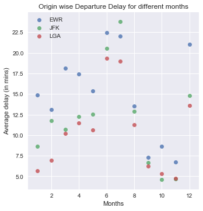

[figure not shown]

```python
# Exploring the seasonal patterns in average departure delay in mins by Month
#Group the departure delay monthwise
dep_delay_monthwise = flights_df.groupby(['month', 'origin'])['dep_delay'].mean()
#Series to Dataframe
dep_delay_monthwise_df = pd.DataFrame(dep_delay_monthwise).reset_index()
dep_delay_monthwise_df.columns = ['Month', 'Origin', 'Delay']

#Scatterplot of departure delay for different months and origins
sns.lmplot(x="Month", y="Delay", data=dep_delay_monthwise_df, fit_reg=False, hue='Origin', legend = False)
plt.title('Origin wise Departure Delay for different months')
plt.xlabel('Months')
plt.ylabel('Average delay (in mins)')
plt.legend(loc='upper left')
plt.show()

# Exploring the seasonal patterns in total number of delayed by Month
plt.plot(delayed_days.groupby('Month').count())
plt.xlabel('Months')
plt.ylabel('Total Number of Delayed Flights', size = 12)
plt.title('Total Number of Delayed Flights by Month')
plt.show()
```

### (e)

On average, how do departure delays vary over the course of a day?

[figure not shown]

```python
#Group the departure delay hourwise
dep_delay_hourwise = flights_df.groupby('hour')['dep_delay'].mean()
dep_delay_hourwise = pd.DataFrame(dep_delay_hourwise).reset_index()
dep_delay_hourwise.columns = ['Hour', 'Delay']

# Barplot of average departure delay over course of day
plt.bar(range(25), dep_delay_hourwise.Delay, color = 'maroon')
plt.xlabel('Hour of Day')
plt.ylabel('Avg Departure Delay')
plt.title('Avg Departure Delay over the course of a day')
plt.show()
```

#### From the above plot, we can see that the departure delays are high during the night times, especially between 10pm and 4am.

## Question 3

Which flight departing NYC in 2013 flew the fastest?

Note: compute the speed as distance/time.

```python
#Computing speed as distance/time
flights_df['speed'] = flights_df.distance/(flights_df.air_time/60)
details = ['carrier','tailnum','flight','speed']
fastest_flight = flights_df.sort_values('speed', ascending = False)[details].head(1)
fastest_flight
```

|  | carrier | tailnum | flight | speed |
| --- | --- | --- | --- | --- |
| 216447 | DL | N666DN | 1499 | 703.384615 |

#### The fastest flight that departed NYC in 2013 belonged to DL(Delta Air Lines Inc.). Its tailnumber is N666DN and flight no is 1499. Its speed was 703.38 mph.

## Question 4

Which flights (i.e. carrier + flight + dest) happen every day? Where do they fly to?

```python
# Adding the Date column by concatenating yyyy-mm-dd
flights_df['date'] = flights_df['year'].astype(str) + "-" + flights_df['month'].astype(str) + "-" + flights_df['day'].astype(str)

# Concatenate the required flight details to a new column
flights_df['comb_det'] = flights_df['carrier'].astype(str) + ' ' + flights_df['flight'].astype(str) + ' ' + flights_df['dest'].astype(str)

#Check if the datset has data for all 365 days
len(flights_df.date.unique())

# Grouping by flight and date to find the details of flights that flew on each day
flights_det_byDate = flights_df.groupby(['comb_det','date']).count()

# Remove the date and combined_det index
flights_det_byDate.reset_index(level=0, inplace=True)
flights_det_byDate.reset_index(level=0, inplace=True)

#Rename the column name
flights_det_byDate.rename(columns={'Unnamed: 0':'Count'}, inplace = True)

# Get the number of days each flight flew
flights_det_byDate = flights_det_byDate.groupby('comb_det').count().sort_values('Count', ascending = False)
flights_det_byDate

#Remove the combined_det index
flights_det_byDate.reset_index(level=0, inplace=True)

# Filter the flights that flew on all days
flights_all_days_list = flights_det_byDate[flights_det_byDate['Count'] == 365]['comb_det']
print(flights_all_days_list)
```

```
0       UA 15 HNL
1      B6 371 FLL
2      AA 181 LAX
3      B6 219 CLT
4      AA 119 LAX
5      B6 703 SJU
6     DL 2391 TPA
7     AA 1357 SJU
8     EV 5712 IAD
9      VX 251 LAS
10    AA 1611 MIA
11     VX 413 LAX
12    DL 2159 MCO
13     B6 431 SRQ
14     VX 407 LAX
15      AA 59 SFO
16    B6 1783 MCO
17     B6 359 BUR
Name: comb_det, dtype: object
```

```python
# Getting the destinations of the flights that fly everyday
destinations = []
for flight in flights_all_days_list.astype(str):
    destinations.append(flight[len(flight)-3:])
destinations = set(destinations)
print("\nList of cities that has flights everyday from NYC", destinations)
```

```
List of cities that has flights everyday from NYC {'MCO', 'SFO', 'CLT', 'LAS', 'BUR', 'TPA', 'SRQ', 'HNL', 'LAX', 'IAD', 'MIA', 'FLL', 'SJU'}
```

## Question 5

Develop one research question you can address using the nycflights2013 dataset. Provide two visualizations to support your exploration of this question. Discuss what you find.

Note: we'll using matplotlib for plotting in this course, but you can use something else too.

#### The research question I would like to explore is

## Which 5 cities had the most and least average delayed flights?

#### I would like to explore this question in two parts.

##### Part 1: Top 5 cities with maximum/minimum average departure delay from NYC

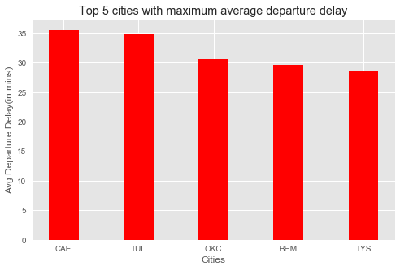

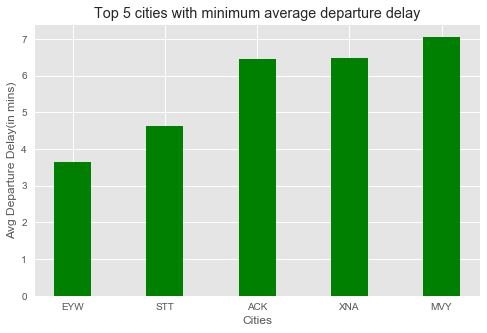

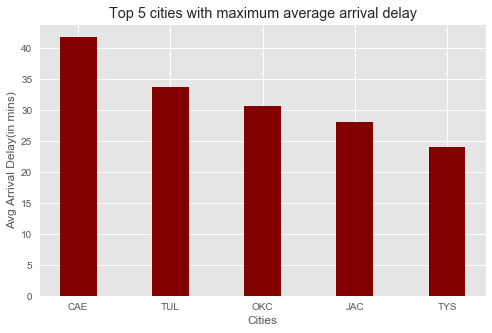

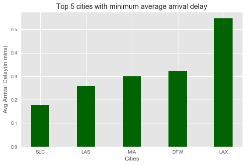

```python
##### Part (1a) Top 5 cities with maximum average departure delay from NYC
##Group the data based on destination cities and get average of departure delay
flights_cities = flights_df.groupby('dest')['dep_delay'].mean()

#Series to dataframe
flights_cities_df = pd.DataFrame(flights_cities).reset_index()
flights_cities_df.columns = ['City', 'Delay']
top_max_dep_delay = flights_cities_df.sort_values('Delay', ascending = False).head(5)

# Barplot of top 5 cities with maximum average departure delay
y_pos = np.arange(len(top_max_dep_delay))
plt.figure(figsize=(8,5))
plt.bar(y_pos, top_max_dep_delay.Delay, color = 'red', width = 0.4)
plt.xticks(y_pos, top_max_dep_delay.City)
plt.xlabel('Cities')
plt.ylabel('Avg Departure Delay(in mins)')
plt.title('Top 5 cities with maximum average departure delay')
plt.show()

##### Part (1b) Top 5 cities with minimum average departure delay from NYC
top_min_dep_delay = flights_cities_df.sort_values('Delay', ascending = True)
top_min_dep_delay = top_min_dep_delay[top_min_dep_delay.Delay > 0]
top_min_dep_delay = top_min_dep_delay.head(5)

# Barplot of top 5 cities with minimum average departure delay
y_pos = np.arange(len(top_min_dep_delay))
plt.figure(figsize=(8,5))
plt.bar(y_pos, top_min_dep_delay.Delay, color = 'green', width = 0.4)
plt.xticks(y_pos, top_min_dep_delay.City)
plt.xlabel('Cities')
plt.ylabel('Avg Departure Delay(in mins)')
plt.title('Top 5 cities with minimum average departure delay')
plt.show()


##### Part (2a) Top 5 cities with maximum average arrival delay to NYC
##Group the data based on destination cities and get average of the arrival delay
flights_cities_arr = flights_df.groupby('dest')['arr_delay'].mean()

#Series to dataframe
flights_cities_arr_df = pd.DataFrame(flights_cities_arr).reset_index()
flights_cities_arr_df.columns = ['City', 'Delay']
top_max_arr_delay = flights_cities_arr_df.sort_values('Delay', ascending = False).head(5)

# Barplot of top 5 cities with maximum average arrival delay
y_pos = np.arange(len(top_max_arr_delay))
plt.figure(figsize=(8,5))
plt.bar(y_pos, top_max_arr_delay.Delay, color = 'maroon', width = 0.4)
plt.xticks(y_pos, top_max_arr_delay.City)
plt.xlabel('Cities')
plt.ylabel('Avg Arrival Delay(in mins)')
plt.title('Top 5 cities with maximum average arrival delay')
plt.show()

##### Part (2b) Top 5 cities with minimum average arrival delay from NYC
top_min_arr_delay = flights_cities_arr_df.sort_values('Delay', ascending = True)
top_min_arr_delay = top_min_arr_delay[top_min_arr_delay.Delay > 0]
top_min_arr_delay = top_min_arr_delay.head(5)

# Barplot of top 5 cities with minimum average arrival delay
y_pos = np.arange(len(top_min_arr_delay))
plt.figure(figsize=(8,5))
plt.bar(y_pos, top_min_arr_delay.Delay, color = 'darkgreen', width = 0.4)
plt.xticks(y_pos, top_min_arr_delay.City)
plt.xlabel('Cities')
plt.ylabel('Avg Arrival Delay(in mins)')
plt.title('Top 5 cities with minimum average arrival delay')
plt.show()
```

#### From the plots that show the airports with minimum delays(departure and arrival), we could not find any common airports. All the airports that has the minimum arrival delay are different from the ones that has the minimum departure delay. Thus we could not see any patterns as in case of the airports with maximum delays

## Question 6

What weather conditions are associated with flight delays leaving NYC? Use graphics to explore.

Note: you need to use 'weather.csv' dataset

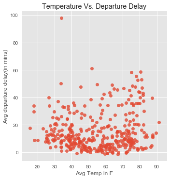

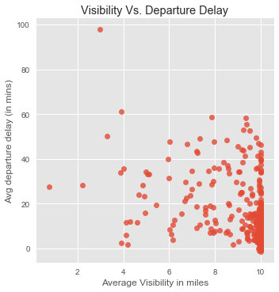

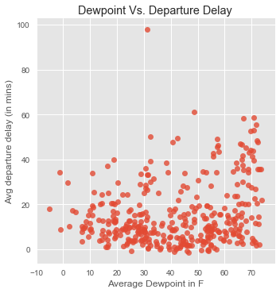

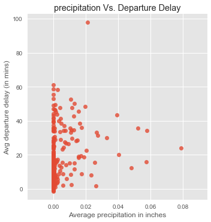

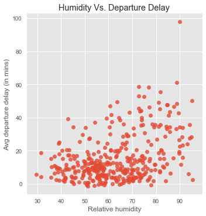

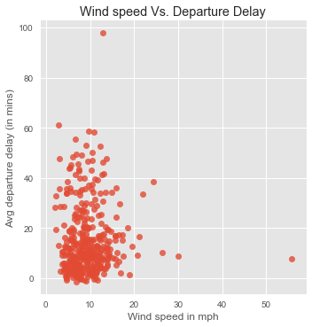

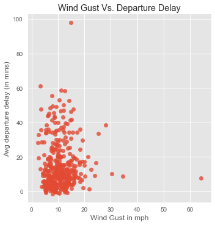

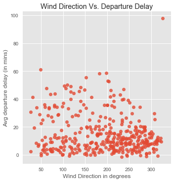

```python
# Read the weather data
weather_df= pd.read_csv('C:/Users/mailt/Documents/IMT574/data/weather.csv.bz2')

#Aggregate the weather details for each day
weather_df = pd.DataFrame(weather_df.groupby(['year','month','day','origin']).mean())

#Remove the indexes formed by grouping
weather_df.reset_index(level = [0, 1, 2, 3], inplace = True)

#Combine the weather data and flight data
# Aggregate the flight data and remove grouped indices
flights_agg_df = flights_df.groupby(['year','month','day','origin']).mean()
flights_agg_df.reset_index(level = [0, 1, 2, 3], inplace = True)

#Eliminate the unwanted columns
flights_agg_df = flights_agg_df[['origin','year','month','day','dep_delay','arr_delay']]

# Merging datasets
flights_weather_df = pd.merge(weather_df,flights_agg_df, on = ['year','month','day','origin'], how = 'inner')


#Plotting Temperature vs average departure delay
sns.lmplot(x="temp", y="dep_delay", data=flights_weather_df, fit_reg = False)
plt.title('Temperature Vs. Departure Delay')
plt.xlabel('Avg Temp in F')
plt.ylabel('Avg departure delay(in mins)')

#Plotting Visibility vs average departure delay
sns.lmplot(x="visib", y="dep_delay", data=flights_weather_df, fit_reg = False)
plt.xlabel('Average Visibility in miles')
plt.ylabel('Avg departure delay (in mins)')
plt.title('Visibility Vs. Departure Delay')

#Plotting dewpoint vs average departure delay
sns.lmplot(x="dewp", y="dep_delay", data=flights_weather_df, fit_reg = False)
plt.xlabel('Average Dewpoint in F')
plt.ylabel('Avg departure delay (in mins)')
plt.title('Dewpoint Vs. Departure Delay')

#Plotting Precipitation vs average departure delay
sns.lmplot(x="precip", y="dep_delay", data=flights_weather_df, fit_reg = False)
plt.xlabel('Average precipitation in inches')
plt.ylabel('Avg departure delay (in mins)')
plt.title('precipitation Vs. Departure Delay')

#Plotting Humidity vs average departure delay
sns.lmplot(x="humid", y="dep_delay", data=flights_weather_df, fit_reg = False)
plt.xlabel('Relative humidity')
plt.ylabel('Avg departure delay (in mins)')
plt.title('Humidity Vs. Departure Delay')

#Plotting Wind speed vs average departure delay
sns.lmplot(x="wind_speed", y="dep_delay", data=flights_weather_df, fit_reg = False)
plt.xlabel('Wind speed in mph')
plt.ylabel('Avg departure delay (in mins)')
plt.title('Wind speed Vs. Departure Delay')

#Plotting Wind Gust vs average departure delay
sns.lmplot(x="wind_gust", y="dep_delay", data=flights_weather_df, fit_reg = False)
plt.xlabel('Wind Gust in mph')
plt.ylabel('Avg departure delay (in mins)')
plt.title('Wind Gust Vs. Departure Delay')

#Plotting Wind Direction vs average departure delay
sns.lmplot(x="wind_dir", y="dep_delay", data=flights_weather_df, fit_reg = False)
plt.xlabel('Wind Direction in degrees')
plt.ylabel('Avg departure delay (in mins)')
plt.title('Wind Direction Vs. Departure Delay')
```